# Chi-squared tests

Emma Rand

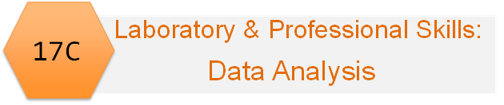

[figure not shown]

Emma Rand. (2022). Data Analysis in R (BIO00017C) 2020: 2022 (v1.1). Zenodo. https://doi.org/10.5281/zenodo.6359475

# Introduction

## Session overview

In this workshop you will get practice analysing data that are counts falling into mutually exclusive categories using two types of chi-squared test choosing between these two tests.

## Learning Outcomes

By actively following the materials and carrying out the independent study before and after the contact hours the successful student will be able to:

- recognise when to use chi-squared Goodness of Fit and Contingency tests (MLO 2)
- be able to carry out, interpret and report scientifically both types in R (MLO 3 and 4)

## Philosophy

Workshops are not a test. It is expected that you often don’t know how to start, make a lot of mistakes and need help. Do not be put off and don’t let what you can not do interfere with what you can do. You will benefit from collaborating with others and/or discussing your results. It is expected that you are familiar with independent study content before the workshop. However, you need not remember or understand every detail as the workshop should build and consolidate your understanding. You may wish to refer to the independent study materials for reference.

Materials are indexed here: https://3mmarand.github.io/BIO00017C-Data-Analysis-in-R-2020/

## Key

These four symbols are used at the beginning of each instruction so you know where to carry out the instruction.

is something you need to do on your computer. It may be opening programs or documents or locating a file.

is something you should do in RStudio. It will often be typing a command or using the menus but might also be creating folders, locating or moving files.

is something you should do in your browser on the internet. It may be searching for information, going to the VLE or downloading a file.

is question for you to think about an answer. You will usually want to record your answers in your script for future reference.

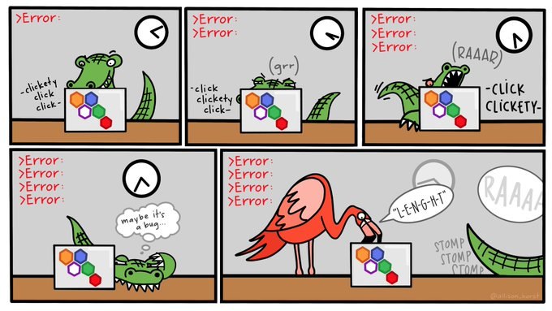

Artwork by Allison Horst

# Getting started

Start RStudio from the Start menu.

Make an RStudio project for this workshop by clicking on the drop-down menu on top right where it says Project: (None) and choosing New Project and then New Directory, then New Project. Navigate to the “data-analysis-in-r” folder. Name the RStudio Project ‘workshop8’.

On the Files tab make a folder `data-raw`

Make a new script then save it with a name like `analysis.R` to carry out the rest of the work.

Load the `tidyverse`:

```r
library(tidyverse)
```

# Exercises

## Inductions

In a local maternity hospital, the total numbers of births induced on each day of the week over a six week period were recorded as follows:

| Day | No.inductions |
| --- | --- |
| Monday | 43 |
| Tuesday | 36 |
| Wednesday | 35 |
| Thursday | 38 |
| Friday | 48 |
| Saturday | 26 |
| Sunday | 24 |
| Total | 250 |

### Inductions - coding the ${\chi}^2$

We can use a chi-squared test to ascertain whether there is a pattern in these data that might suggest that surgeons are more reluctant to perform inductions on some days than on others.

Make a vector `obs` that holds the number of inductions on each day.

What is your null hypothesis and what type of test is required?

We can carry out a Goodness of Fit chi-squared test on these data by coding the how the test works ourselves. If the null hypothesis is true, 1/7th of inductions would be expected to occur each day *i.e.,* 1/7th of 250

Assign the total number of inductions to a variable called `totalinductions`

```r
# the total number of inductions
totalinductions <- sum(obs)
```

Now calculate the expected values:

```r
# the expected values
# note that R multiplies every element in the c() by totalinductions
exp <- c(1/7, 1/7, 1/7, 1/7, 1/7, 1/7, 1/7) * totalinductions
```

The formula for chi-squared is: ${\chi}^2 = \Sigma \frac{(O - E)^2}{E}$

We can write this in R using:

```r
# calculate the chisquared
chisqd <- sum(((obs - exp)^2) / exp)
```

We have ${\chi}^2 =$ 12.36

The degrees of freedom for a chi-squared Goodness of fit test are the number of categories minus one.

Calculate and assign the *d.f.* to a variable called `df`

The $p$ value can be calculated with:

```r
pchisq(chisqd, df = df, lower.tail = FALSE)
```

```
## [1] 0.05440298
```

This `pchisq()` function does for a chi-squared distribution what the `pnorm()` function does for the normal distribution and `pt()` does for the *t* distribution: it gives the probability of getting a value of 12.36 or more (since `lower.tail = FALSE`)

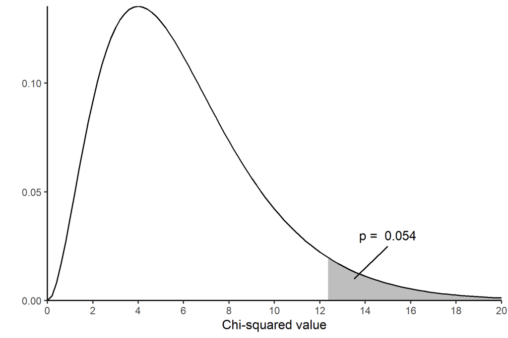

What do you conclude about the pattern of birth inductions?

We could have decided to test a different null hypothesis. Instead of testing whether we had 1/7 of the inductions each day (7 categories) we could test whether we had 2/7 and 5/7 in two categories, ‘weekends’ and ‘weekdays’.

You can pool your observed data like this:

```r
# Combining the weekdays and the weekend days
obs2 <- c(sum(obs[1:5]), sum(obs[6:7]))
```

Then calculate the expected values:

```r
exp2 <- c(5/7, 2/7) * totalinductions
```

Carry out the Goodness of fit test on this two-category situation.

Do your conclusions alter?

### Inductions - alternative method (inbuilt test)

We have carried out a Goodness of Fit chi-squared test by coding the how the test works ourselves. R also has an inbuilt function. The inbuilt function `chisq.test()` is used like this:

```r
chisq.test(obs)
```

```
##
##  Chi-squared test for given probabilities
##
## data:  obs
## X-squared = 12.36, df = 6, p-value = 0.0544
```

This looks much easier but it is only that straightforward when the expected numbers are equal in each category, *i.e.*, 1:1:1:1:1:1:1

For other cases, such as we had for on combining the weekdays and the weekend days, then we have to give the expected ratios.

Use the inbuilt function `chisq.test()` when expected values are not equal in each category:

```r
exp2 <- c(5/7, 2/7)
chisq.test(obs2, p = exp2)
```

```
##
##  Chi-squared test for given probabilities
##
## data:  obs2
## X-squared = 9, df = 1, p-value = 0.0027
```

**Top Tip**

R has an inbuilt chi-squared test, `chisq.test()` which can be used for Goodness of fit tests. By default it tests against equal numbers in each category. If you want test other null hypotheses, you must give the expected proportions with the `p` argument

### Inductions - alternative data format

The data we were given was already tabulated however, data often comes to us with an observation in each row. In this case that would mean a column of 250 values which indicated which day an induction was performed. Data formatted this way is in inductions.txt.

It might seem strange to you that data like these would come in this form but it is actually common when a study has collected many variables. For example, imagine the hospital collected data about every birth, you might have a dataframe similar to this:

In such a case you might add a column for day calculated from the date (using the function `wday()`)

|  | date | mass_kg | maternal_age | cesarean | induction | epidural |
| --- | --- | --- | --- | --- | --- | --- |
| 1 | 2021-01-08 | 3.658 | 31.83 | 0 | 0 | 0 |
| 2 | 2021-02-01 | 3.346 | 21.81 | 0 | 0 | 0 |
| 3 | 2021-02-21 | 3.678 | 31.72 | 0 | 0 | 0 |
| 4 | 2021-03-03 | 4.294 | 32.89 | 0 | 0 | 1 |
| 5 | 2021-03-04 | 3.781 | 32.81 | 0 | 0 | 0 |
| 6 | 2021-03-10 | 3.024 | 31.42 | 0 | 0 | 1 |
| 7 | 2021-04-21 | 3.624 | 36.74 | 0 | 0 | 1 |
| 8 | 2021-05-10 | 4.044 | 23.82 | 1 | 0 | 1 |
| 9 | 2021-06-15 | 4.101 | 30.72 | 1 | 0 | 0 |
| 10 | 2021-08-05 | 3.401 | 28.03 | 0 | 0 | 0 |

[output cut: 10 more lines]

Save a copy of inductions.txt to the `data-raw` folder and read it in.

We can tabulate the data and assign it using the `table()` command:

```r
indtab <- table(inductions$day)
indtab
```

```
##
##   fri   mon   sat   sun thurs  tues   wed
##    48    43    26    24    38    36    35
```

The `table()` outputs the days in alphabetical order which is a common default in R. This does not matter since days are just arbitrary categories for the chi-squared test.

Now carry out the 7 category goodness of fit like this:

```r
chisq.test(indtab)
```

```
##
##  Chi-squared test for given probabilities
##
## data:  indtab
## X-squared = 12.36, df = 6, p-value = 0.0544
```

You have the same ${\chi}^2$ and $p$ value as previously.

### Illustrating

We could create a figure using ggplot like this:

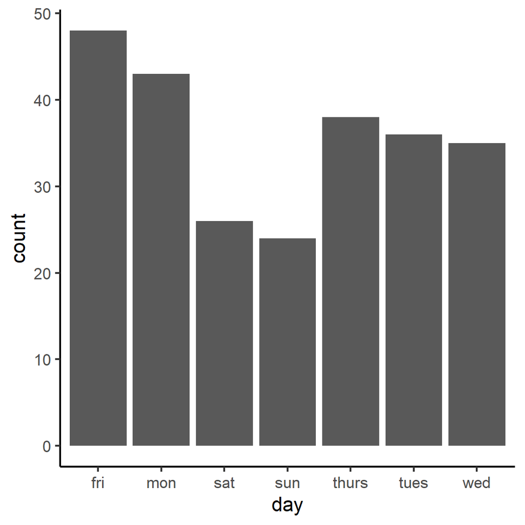

```r
ggplot(data = inductions, aes(x = day)) +
  geom_bar() +
  theme_classic()
```

A `geom`’s `stat` determines what the `geom` plots. Look up `geom_bar()` with:

```r
?geom_bar
```

Notice that the default `stat` for `geom_bar()` is `count` which means it counts the number of each day *for us*. Other `stat`s are `identity`, `density` and `bin`.

**Top Tip**

`geom_bar()` will tabulate raw data before plotting. `geom_col()` can be used for data which are already tabulated. What a `geom` does is determined by its `stat` argument.

What is not so great in this plot is the alphabetical ordering. We can reorder the categories with `fct_relevel()` (“factor relevel”). Reordering factor levels is something we quite often want to do to create the most useful plots.

Put the days of the week in order:

```r
inductions$day <- fct_relevel(inductions$day,
                              "mon",
                              "tues",
                              "wed",
                              "thurs",
                              "fri",
                              "sat",
                              "sun")

levels(inductions$day)
```

```
## [1] "mon"   "tues"  "wed"   "thurs" "fri"   "sat"   "sun"
```

Redraw the figure also making sure the bars sit on the axis and the axis labels are improved. I’ve added `coord_flip()` too.

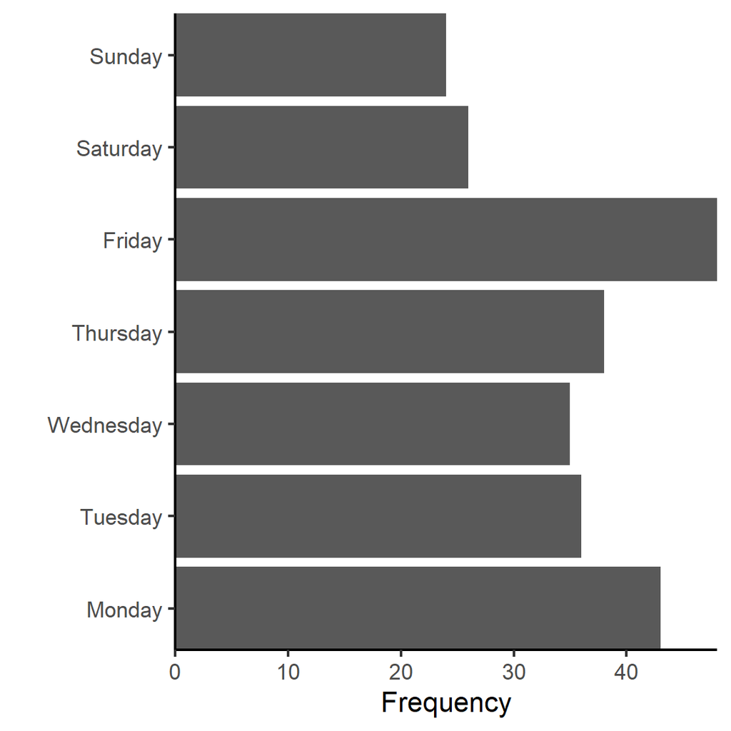

## Blood group and ulcers

A human geneticist is interested in whether there is an association between ABO blood group phenotypes and the incidence of peptic ulcers. He found that in a sample of 477 blood group O people 65 had peptic ulcers whereas in a sample of 387 blood group A people 31 had peptic ulcers.

Draw a table of these data (on a piece of paper).

What is your null hypothesis and what type of test is required?

### Blood group and ulcers - inbuilt test

Make a vector `obs` that holds the observed numbers. For the moment, don’t worry about what order they are in:

For a contingency chi squared test, the inbuilt chi-squared test can be used in a straightforward way. However, we need to structure our data as a 2 x 2 table rather than as a 1 x 4 vector. A 2 x 2 table can be created with the `matrix()` function. We can also name the rows and columns which helps us interpret the results.

To create a list containing two elements which are vectors for the two groups in each variable we do:

```r
# list of two elments
# the two variables are whether someone has an ulcer or not and whether they are blood group O or A
vars <- list(ulcer = c("yes","no"), blood = c("O", "A"))
vars
```

```
## $ulcer
## [1] "yes" "no"
##
## $blood
## [1] "O" "A"
```

Now we can create the matrix from our vector of numbers `obs` and use our list `vars` to give the column and row names:

```r
ulcers <- matrix(obs, nrow = 2, dimnames = vars)
ulcers
```

```
##      blood
## ulcer   O   A
##   yes  65  31
##   no  412 356
```

Check the content of `ulcers` and recreate if the numbers are not in the correct place (*i.e.*, do not match your table)

Run a contingency chi-squared with:

```r
chisq.test(ulcers, correct = FALSE)
```

```
##
##  Pearson's Chi-squared test
##
## data:  ulcers
## X-squared = 6.824, df = 1, p-value = 0.008994
```

```r
# you should look up the command in the manual to see what correct = FALSE does
```

To help us discover what is the direction of any deviation from the null hypothesis it is helpful to see what the expected values were. These are accessible in the `$expected` variable in the output value of the `chisq.test()` method (See the manual!).

View the expected values with:

```r
chisq.test(ulcers, correct = FALSE)$expected
```

```
##      blood
## ulcer   O   A
##   yes  53  43
##   no  424 344
```

What do you conclude about the association between ABO blood group and peptic ulcers?

### Blood group and ulcers- alternative data format.

The data we were given was already tabulated. There are raw data in blood_ulcers.txt. Examine this file and compare its content to inductions.txt

Save a copy of blood_ulcers.txt to the ‘data-raw’ folder

Read the data in to R and check the structure.

Notice that we have two variables this time.

We can tabulate the data and assign it using the `table()` command:

```r
ulctab <- table(blood_ulcers$blood, blood_ulcers$ulcer)
# examine the result
ulctab
```

```
##
##      no yes
##   A 356  31
##   O 412  65
```

We need to give both variables to cross tabulate.

Now carry out the contingency chi-squared like this:

```r
chisq.test(ulctab, correct = FALSE)
```

```
##
##  Pearson's Chi-squared test
##
## data:  ulctab
## X-squared = 6.824, df = 1, p-value = 0.008994
```

## Genetics

In a particular species of ground beetle, red and yellow elytral colours are controlled by alleles at one locus, with red (R) dominant to yellow (r). Spotted and plain elytral patterns are controlled by alleles at another locus, with spotted elytra (S) dominant to plain (s). You set up a cross between two indivuals that are heterozygous at both loci (RrSs). If the two loci are unlinked you would expect a phenotype ratio of 9 : 3 : 3 : 1 ratio of red/spotted : red/plain : yellow/spotted : yellow plain, respectively. The numbers you actually observe for these four phenotypes are: 79, 17, 19 and 20 (total = 135).

Make a vector `obs` that holds the number of phenotype .

What is your null hypothesis and what type of test is required?

Carry out the appropriate chi-squared test on these data either with or without using inbuilt test, whatever you prefer.

What do you conclude about results?

# Independent study

## Slug colour forms - tabulated

The slug *Arion ater* has three major colour forms, black, chocolate brown and red. Sampling in population X revealed 27 black, 17 brown and 9 red individuals, whereas in population Y the corresponding numbers were 39, 10 and 21. Create an appropriate data structure and run the appropriate chi-squared test

## Slug colour forms - raw data

The raw, untabulated data are in slugs.txt. Perform the test on these data.

# The Code files

These contain all the code needed in the workshop even where it is not visible on the webpage.

Rmd file The Rmd file is the file I use to compile the practical. Rmd stands for R markdown. It allows R code and ordinary text to be interweaved to produce well-formatted reports including webpages. If you right-click on the link and choose Save-As, you will be able to open the Rmd file in RStudio. Alternatively, [View in Browser](https://github.com/3mmaRand/BIO00017C-Data-Analysis-in-R-2020/blob/main/workshops/08ChiSquaredTests.Rmd).

Plain script file This is plain script (.R) version of the practical generated from the Rmd. Again, you can save this and open it RStudio. Alternatively, [View in Browser](https://github.com/3mmaRand/BIO00017C-Data-Analysis-in-R-2020/blob/main/scripts/08ChiSquaredTests.R).

Pages made with `rmarkdown` (Allaire Xie, et al., 2019a; Xie Allaire, et al., 2018a), `kableExtra` (Zhu, 2019a), `RefManager` (McLean, 2014)

# References

Allaire, J., Y. Xie, et al. (2019a). *rmarkdown: Dynamic Documents for R*. R package version 1.16. URL: https://github.com/rstudio/rmarkdown.

McLean, M. W. (2014). *Straightforward Bibliography Management in R Using the RefManager Package*. arXiv: 1403.2036 [cs.DL]. URL: https://arxiv.org/abs/1403.2036.

Xie, Y., J. Allaire, et al. (2018a). *R Markdown: The Definitive Guide*. ISBN 9781138359338. Boca Raton, Florida: Chapman and Hall/CRC. URL: https://bookdown.org/yihui/rmarkdown.

Zhu, H. (2019a). *kableExtra: Construct Complex Table with ‘kable’ and Pipe Syntax*. R package version 1.1.0. URL: https://CRAN.R-project.org/package=kableExtra.

# Please cite as:

Emma Rand. (2022). Data Analysis in R (BIO00017C) 2020: 2022 (v1.1). Zenodo. https://doi.org/10.5281/zenodo.6359475

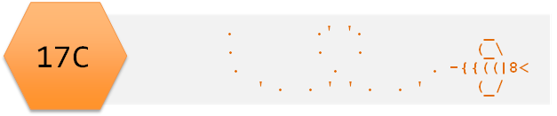